# Práctica 08 - Modelos Ocultos de Markov

### Introducción a la práctica

Un modelo oculto de Markov (HMM – Hidden Markov Model, por sus siglas en inglés) se basa en la argumentación de una cadena de Markov, la cual es un modelo que especifica hechos sobre las probabilidades en que se da una secuencia de variables aleatorias, llamadas estados, cada uno de los cuales puede tomar valores de un conjunto [1]. Estos conjuntos pueden ser símbolos representando cualquier fenómeno, por ejemplo, datos sobre el clima. Una cadena de Markov especifica una fuerte asunción de que, si queremos predecir el futuro en esa secuencia, lo único que importa es el estado actual [idem]. Así, los estados previos al actual no tienen impacto en futuros estados, salvo en el actual. Esto es, si queremos predecir el clima de mañana, se podría analizar el clima de hoy, pero no está permitido analizar el de ayer

### Cuestionamiento básico previo a la práctica

**¿Qué tipo de problema de ingeniería resuelve un modelo oculto de Markov?**

Predicción, porque brinda las probabilidades de futuros comportamientos

### Procedimiento o desarrollo

1.- Para el desarrollo de la práctica usaremos el paquete HMM desarrollado por Himmelmann [4]. Ingresa al entorno de desarrollo de R.

2.- Primero debes instalar el paquete para manejo de un HMM, el comando a teclear en la consola para poder realizar esa tarea es el siguiente:

install.packages(‘HMM’, repos=‘http://cran.us.r-project.org’)

Una vez que instalas el paquete, debes indicar que usarás la biblioteca de funciones del mismo nombre, por lo que debes teclear:

```r
library(HMM)
```

3.- Ahora considera el siguiente ejemplo. Imagina que puedes observar el clima desde tu ventana, a partir de eso puedes saber si está soleado (S) o nublado (N). S y N son los estados observables. Lo que quieres hacer es inferir, a partir del clima, si un amigo tuyo practica ciclismo (C) o realiza la lectura de un libro (L). Lo que quieres inferir es que si observas que el clima está soleado tu amigo hará ciclismo, pero si está nublado, él se pondrá a leer un libro. La figura 3 muestra el esquema de estados ocultos y observables para tu experimento.

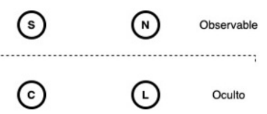

**Figura 3.**Estados ocultos y símbolos observables en tu experimento.

[figure not shown]

[figure not shown]

**Figura 4.**Distribución de probabilidad en las transiciones de estado.

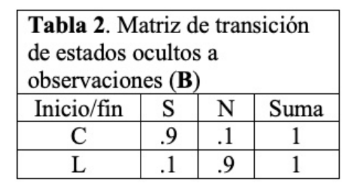

```r
#forward(hmm, observation)
```

Así, para calcular Q, primero debes definir el HMM, lo cual se hace mediante la función initHMM() , misma que tiene la sintaxis siguiente:

```r
#initHMM(States, Symbols, startProbs, transProbs, emissionProbs)
```

en la cual:

- States = vector con los nombres de los estados.
- Symbols = vector con los nombres de los símbolos.
- startProbs = vector con las probabilidades iniciales de los estados (π).
- transProbs = matriz estocástica con las probabilidades de transición entre los estados (A).
- emissionProbs = matriz estocástica con las probabilidades de emisión de los estados (B).

De acuerdo a lo anterior, la función initHMM() debe ejecutarse con los siguientes argumentos:

```r
states <- c("C","L")
symbols <- c("S", "N")
startProbs <- c(0.9, 0.1)
transProbs <- matrix(c(0.8,0.2,0.2,0.8),2)
emissionProbs <- matrix(c(0.9,0.1,0.1,0.9),2)

weather_model=initHMM(states, symbols, startProbs, transProbs, emissionProbs)
```

Para ver el HMM resultante, teclea el siguiente comando, el cual genera la información descrita en la figura 5.

```r
print(weather_model)
```

```
## $States
## [1] "C" "L"
##
## $Symbols
## [1] "S" "N"
##
## $startProbs
##   C   L
## 0.9 0.1
##
## $transProbs
##     to
## from   C   L
##    C 0.8 0.2
##    L 0.2 0.8
##
## $emissionProbs
##       symbols
## states   S   N
##      C 0.9 0.1
##      L 0.1 0.9
```

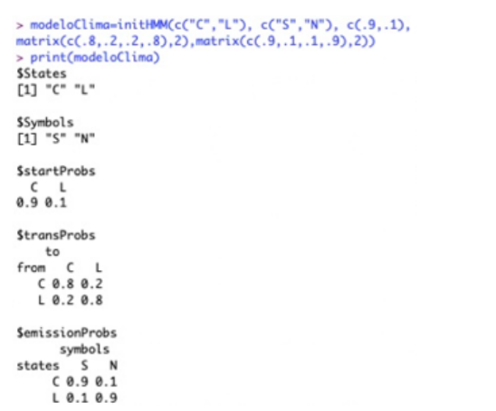

**Figura 5.** El HMM del ejercicio de la práctica.

Ahora que ya tienes el HMM, ejecuta el algoritmo hacia adelante, considerando que tienes O = (S, S, N). El siguiente comando define esas observaciones:

```r
observations <- c("S","S","N")
```

Enseguida aplica el algoritmo hacia adelante (forward) al HMM del clima (objeto modeloClima creado previamente), considerando las observaciones anteriores:

```r
prob_observations <- forward(weather_model,observations)
```

El objeto probObservaciones contiene las probabilidades de las observaciones, para verlas escribe el siguiente comando (observa el resultado en la figura 6):

```r
print(exp(prob_observations))
```

```
##       index
## states    1     2       3
##      C 0.81 0.585 0.04714
##      L 0.01 0.017 0.11754
```

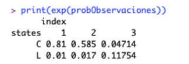

**Figura 6.** Probabilidad de los HMMs.

### Producto a entregar

Archivo PDF con lo siguiente:

- **1.1 Respuesta a cuestionamiento de la práctica.✅**
- **1.2 Solución a los siguientes cuestionamientos:**
- **1.2.1 Describe algunas aplicaciones de los HMMs.**
- Reconocimiento del habla: Las HMMs se utilizan para reconocer el habla y se han utilizado en sistemas como Siri y Google Voice Search.
- Análisis de secuencias de ADN: Las HMMs se utilizan para analizar secuencias de ADN y se han utilizado para identificar genes, exones, intrones y regiones reguladoras.
- Reconocimiento de escritura: Las HMMs se utilizan para reconocer la escritura a mano y se han utilizado en sistemas como el reconocimiento de caracteres de correo postal.
- Procesamiento del lenguaje natural: Las HMMs se utilizan para procesar el lenguaje natural y se han utilizado en sistemas como la traducción automática y la generación de texto.
- Análisis de series de tiempo: Las HMMs se utilizan para analizar series de tiempo y se han utilizado en áreas como la economía, la meteorología y la física.
- Análisis de datos financieros: Las HMMs se utilizan para analizar datos financieros y se han utilizado para predecir tendencias del mercado, identificar patrones de gastos y detectar fraude.
- Biometría: Las HMMs se utilizan en sistemas biométricos, como el reconocimiento de rostros y el reconocimiento de voz para la identificación de personas.
- Modelado de sistemas dinámicos: Las HMMs se utilizan para modelar sistemas dinámicos y se han utilizado en áreas como la ingeniería, la robótica y la biología molecular.
- **1.2.2 Resuelve el problema 1 (probabilidad) de un HMM, considerando las observaciones O = (S, N, S, N).**

```r
# new observations
observations_2 <- c('S','N','S','N')

prob_observations_2 <- forward(weather_model, observations_2)
print(exp(prob_observations_2))
```

```
##       index
## states    1     2       3        4
##      C 0.81 0.065 0.07434 0.006218
##      L 0.01 0.153 0.01354 0.023130
```

- **1.3 Conclusiones del desarrollo de la práctica.**

El HHM se diferencia de los algoritmos de predicción “comunes” por tomar en cuenta patrones indirectamente relacionados al patrón de principal de análisis, la sutilidad de estos patrones en el algoritmo hace que los resultados sean menos aislados a la realidad, en mi opinión.